# comentarios

2023-04-04

## Analisando os Dados

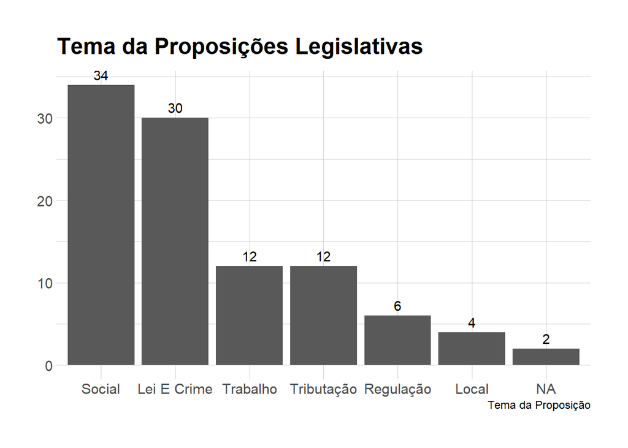

No Gráfico 1 vemos a contagem dos temas das proposições legislativas. Observamos os temas mais frequente tratam e Social e Lei e Crime.

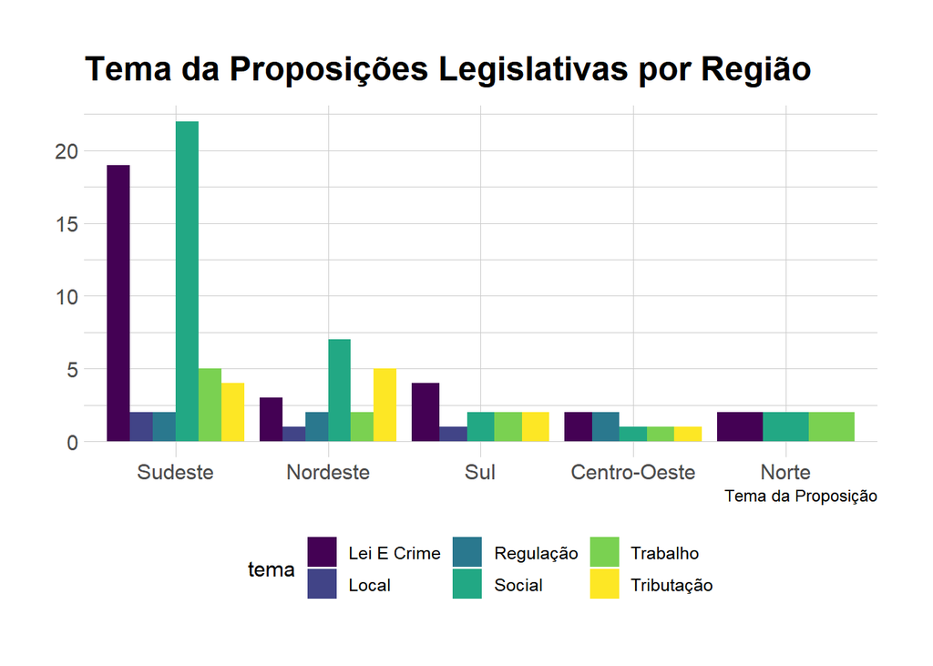

[interactive chart not shown]

No gráfico 3 construímos uma nuvem de palavras a partir do texto das ementas legislativas, onde tanto o tamanho como também a posição mais ao centro denotam a frequência do termo nas ementa. Chamamos atenção para a palavra mais frequente, “fim”, que é presente na maior parte das ementas.

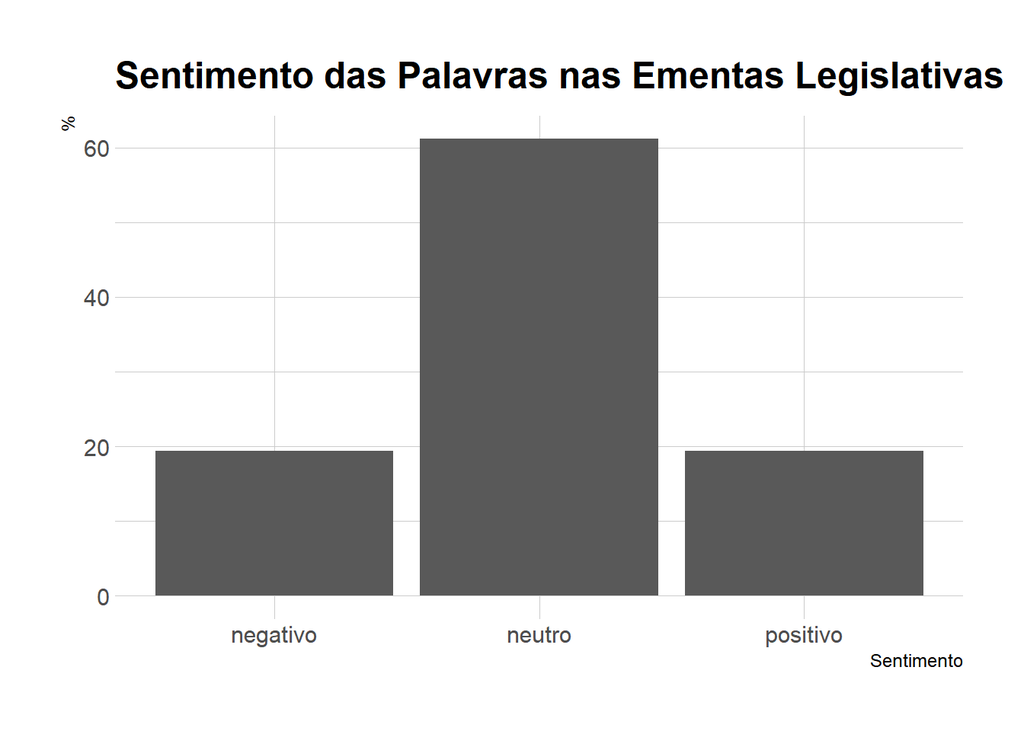

No gráfico 4 analisamos os sentimentos das ementas legislativas utilizando o OpLexicon v3, que é um léxico de sentimento de palavras em português, tendo sua polaridade revisado por linguistas. Observamos que os termos tendem a apresentar sentimentos neutros a sentimentos a sentimentos positivos a negativos.

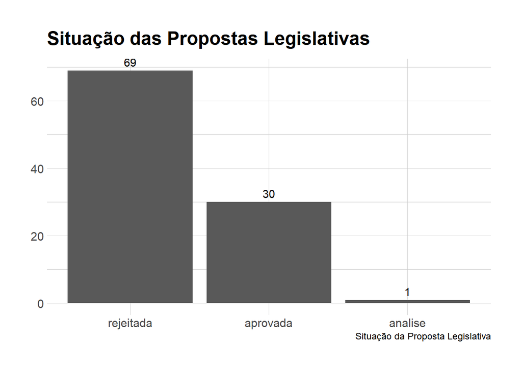

Já no Gráfico 5 observamos a distribuição do status das ementas legislativas. Observamos que a maior parte das ementas, 69%, são rejeitadas.

[interactive chart not shown]

No gráfico 6 apresentamos o wordcloud da justificativa de rejeição das ementas. Chamamos atenção para o termo, lei, art e constituição, já que esses termos aparecem com alta frequência, já que a maior parte da justificativa das ementas se dá por elas serem ilegais, ferindo algum artigo ou a constituição.

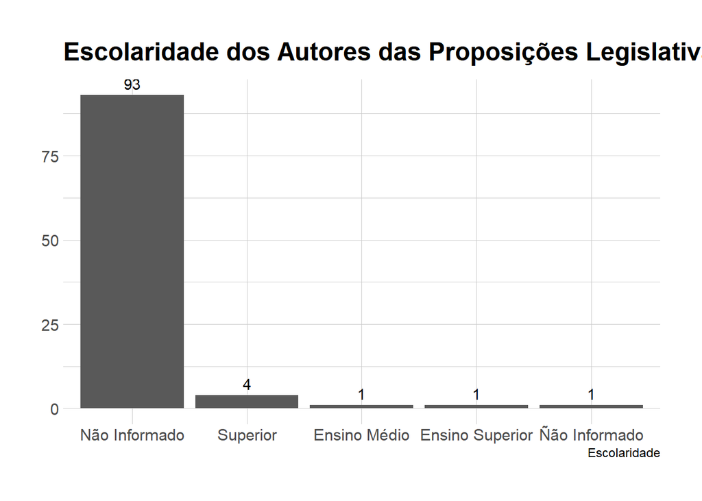

No gráfico 7 observamos a escolaridade do autores. A princípio apostávamos que existe uma associação entre ao alto número de propostas com a baixa escolaridade dos autores, entretanto não pudemos nem confirmar nem rejeitar essa hipótese, já que não temos essa informação para 93% das propostas legislativas.

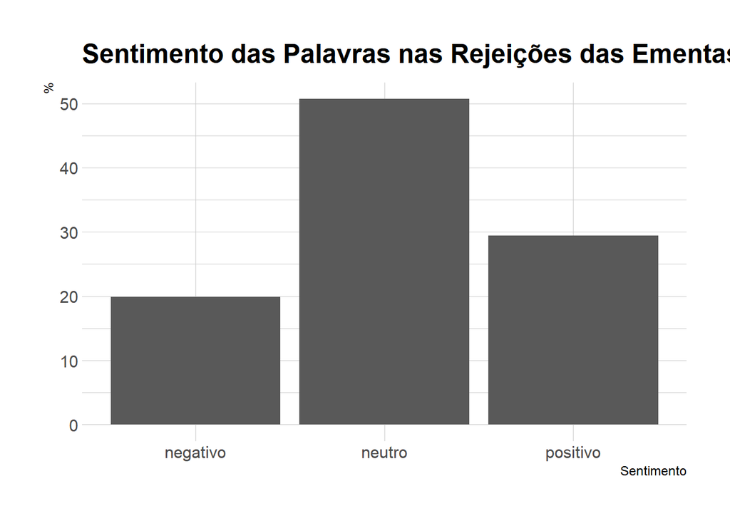

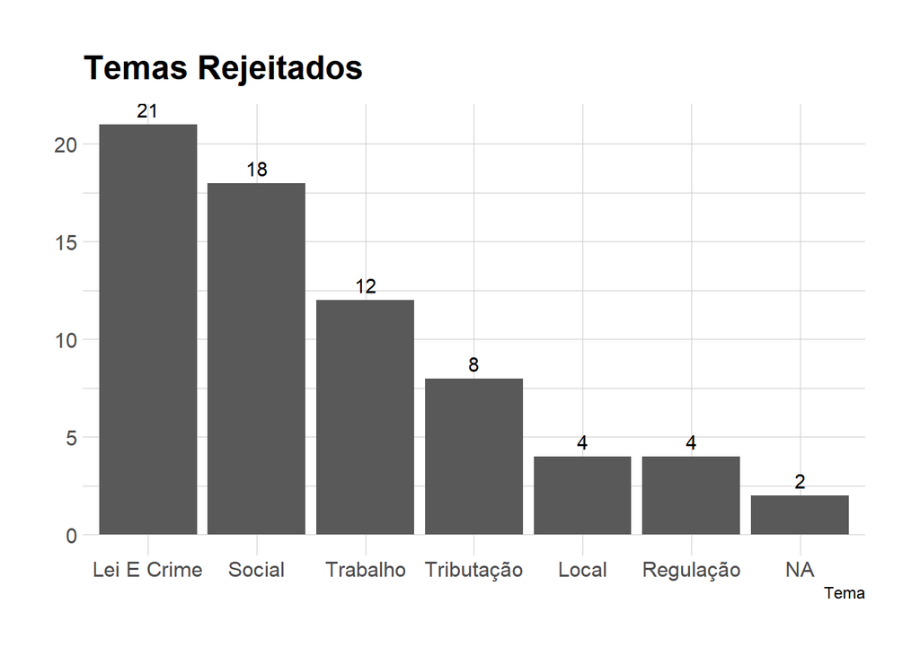

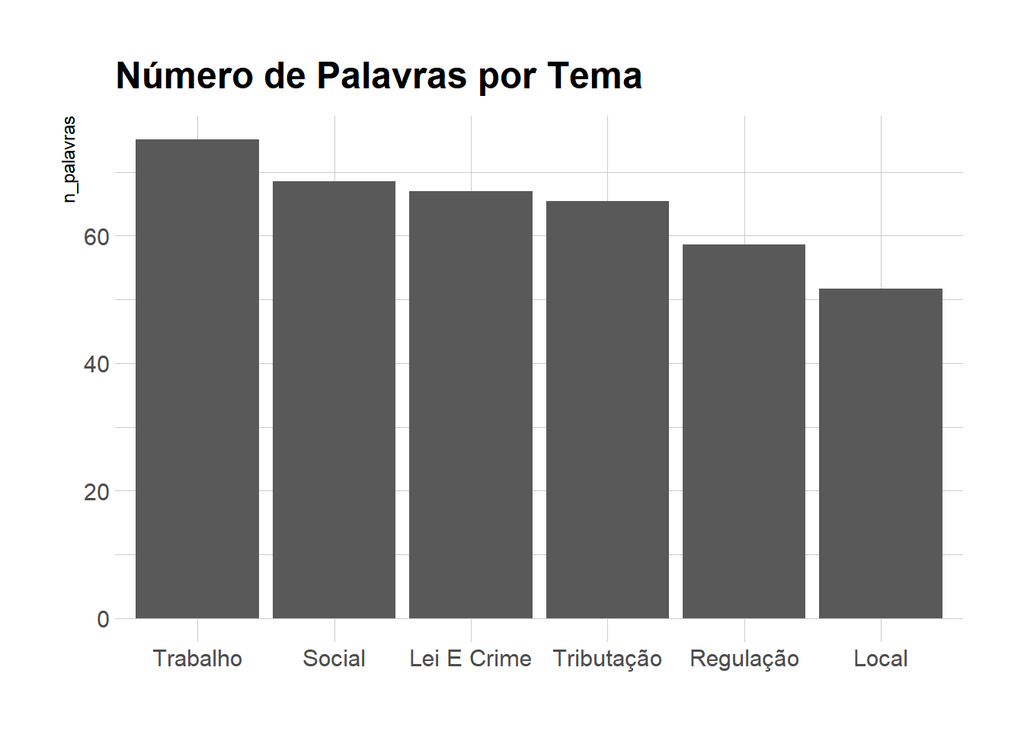

No gráfico 10 apresentamos o número de médio de palavras por tema de proposta legislativa. Aqui propomos o número médio de palavras como um proxy para argumentos utilizados na proposta legislativa, onde temas com maiores médias de palavras apresentam mais argumentos a proposta que temas com menos palavras.

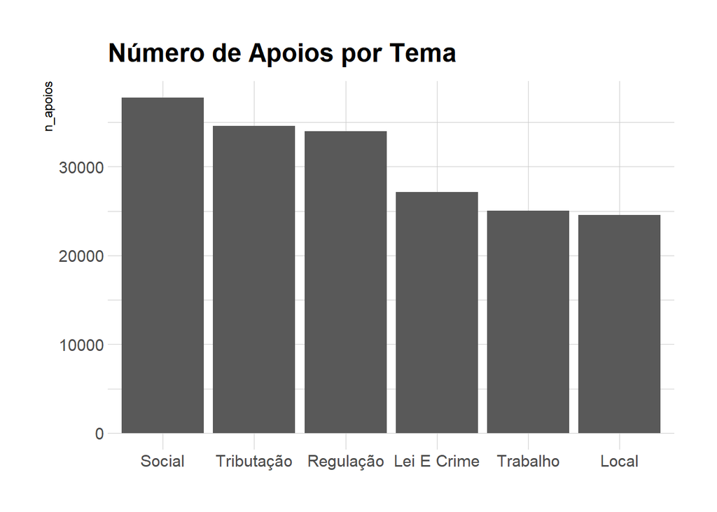

No gráfico 11 apresentamos a média de apoios por tema de proposta legislativa e observamos que os temas mais apoiados são temas sociais e de tributação.